# SDS_final_project

Mohammad Iman Sayyadzadeh

7/21/2021

```r
# Load Libraries
suppressWarnings(suppressMessages(library(ggplot2)))
suppressWarnings(suppressMessages(library(gridExtra)))
suppressWarnings(suppressMessages(library(caret)))
suppressWarnings(suppressMessages(library(performanceEstimation)))
suppressWarnings(suppressMessages(library(scales)))
suppressWarnings(suppressMessages(library(reshape2)))
suppressWarnings(suppressMessages(library(rjags)))
suppressWarnings(suppressMessages(library(jagsUI)))
suppressWarnings(suppressMessages(library(coda)))

# Set path
setwd("C:/Users/Iman/Desktop/sdsp")

# set random seed
seed <- 123

options(scipen=999)

# Read data
data <- read.csv("diabetes.csv")
```

### Illustration of the dataset

I downloaded the Diabetes Data Set from Kaggle which consist of the information of 768 persons(rows) and gives 9 features about each of them (columns) which are:

- Pregnancies
- Glucose
- BloodPressure
- SkinThickness
- Insulin
- BMI
- DiabetesPedigreeFunction
- Age
- Outcome: Class variable (0 or 1)

The objective is to predict based on diagnostic measurements whether a patient is diabetic or not.  
We have 8 explanatory variables and the explained variable(outcome).

```r
summary(data)
```

```
##   Pregnancies        Glucose      BloodPressure    SkinThickness
##  Min.   : 0.000   Min.   :  0.0   Min.   :  0.00   Min.   : 0.00
##  1st Qu.: 1.000   1st Qu.: 99.0   1st Qu.: 62.00   1st Qu.: 0.00
##  Median : 3.000   Median :117.0   Median : 72.00   Median :23.00
##  Mean   : 3.845   Mean   :120.9   Mean   : 69.11   Mean   :20.54
##  3rd Qu.: 6.000   3rd Qu.:140.2   3rd Qu.: 80.00   3rd Qu.:32.00
##  Max.   :17.000   Max.   :199.0   Max.   :122.00   Max.   :99.00
##     Insulin           BMI        DiabetesPedigreeFunction      Age
##  Min.   :  0.0   Min.   : 0.00   Min.   :0.0780           Min.   :21.00
##  1st Qu.:  0.0   1st Qu.:27.30   1st Qu.:0.2437           1st Qu.:24.00
##  Median : 30.5   Median :32.00   Median :0.3725           Median :29.00
##  Mean   : 79.8   Mean   :31.99   Mean   :0.4719           Mean   :33.24
##  3rd Qu.:127.2   3rd Qu.:36.60   3rd Qu.:0.6262           3rd Qu.:41.00
##  Max.   :846.0   Max.   :67.10   Max.   :2.4200           Max.   :81.00
##     Outcome
##  Min.   :0.000
##  1st Qu.:0.000
##  Median :0.000
##  Mean   :0.349
##  3rd Qu.:1.000
##  Max.   :1.000
```

```r
var(data)
```

```
##                           Pregnancies     Glucose BloodPressure SkinThickness
## Pregnancies               11.35405632   13.947131     9.2145382    -4.3900410
## Glucose                   13.94713066 1022.248314    94.4309556    29.2391827
## BloodPressure              9.21453818   94.430956   374.6472712    64.0293962
## SkinThickness             -4.39004101   29.239183    64.0293962   254.4732453
## Insulin                  -28.55523074 1220.935799   198.3784122   802.9799408
## BMI                        0.46977418   55.726987    43.0046951    49.3738694
## DiabetesPedigreeFunction  -0.03742597    1.454875     0.2646376     0.9721355
## Age                       21.57061977   99.082805    54.5234528   -21.3810232
## Outcome                    0.35661805    7.115079     0.6006967     0.5687473
##                               Insulin         BMI DiabetesPedigreeFunction
## Pregnancies                -28.555231   0.4697742              -0.03742597
## Glucose                   1220.935799  55.7269867               1.45487481
## BloodPressure              198.378412  43.0046951               0.26463757
## SkinThickness              802.979941  49.3738694               0.97213555
## Insulin                  13281.180078 179.7751721               7.06668051
## BMI                        179.775172  62.1599840               0.36740469
## DiabetesPedigreeFunction     7.066681   0.3674047               0.10977864
## Age                        -57.143290   3.3603299               0.13077169
## Outcome                      7.175671   1.1006376               0.02747217
##                                  Age    Outcome
## Pregnancies               21.5706198 0.35661805
## Glucose                   99.0828054 7.11507904
## BloodPressure             54.5234528 0.60069671
## SkinThickness            -21.3810232 0.56874728
## Insulin                  -57.1432903 7.17567090
## BMI                        3.3603299 1.10063763
## DiabetesPedigreeFunction   0.1307717 0.02747217
## Age                      138.3030459 1.33695268
## Outcome                    1.3369527 0.22748262
```

```r
# Calculate correlation matrix
cormat <- round(cor(data[,c("Pregnancies","Glucose","BloodPressure","SkinThickness","Insulin","BMI","DiabetesPedigreeFunction","Age")]),2)
cormat
```

```
##                          Pregnancies Glucose BloodPressure SkinThickness
## Pregnancies                     1.00    0.13          0.14         -0.08
## Glucose                         0.13    1.00          0.15          0.06
## BloodPressure                   0.14    0.15          1.00          0.21
## SkinThickness                  -0.08    0.06          0.21          1.00
## Insulin                        -0.07    0.33          0.09          0.44
## BMI                             0.02    0.22          0.28          0.39
## DiabetesPedigreeFunction       -0.03    0.14          0.04          0.18
## Age                             0.54    0.26          0.24         -0.11
##                          Insulin  BMI DiabetesPedigreeFunction   Age
## Pregnancies                -0.07 0.02                    -0.03  0.54
## Glucose                     0.33 0.22                     0.14  0.26
## BloodPressure               0.09 0.28                     0.04  0.24
## SkinThickness               0.44 0.39                     0.18 -0.11
## Insulin                     1.00 0.20                     0.19 -0.04
## BMI                         0.20 1.00                     0.14  0.04
## DiabetesPedigreeFunction    0.19 0.14                     1.00  0.03
## Age                        -0.04 0.04                     0.03  1.00
```

Now we convert the outcome (the explained variable) to a nominal variable.

```r
data$Outcome_factor <- as.factor(data$Outcome)
```

The violin plots are drawn to show the distribution of each covariate based on the outcome variable. If the distribution of each covariate be significantly different for diabetics and non-diabetics, We can candidate that variable to use in the model.

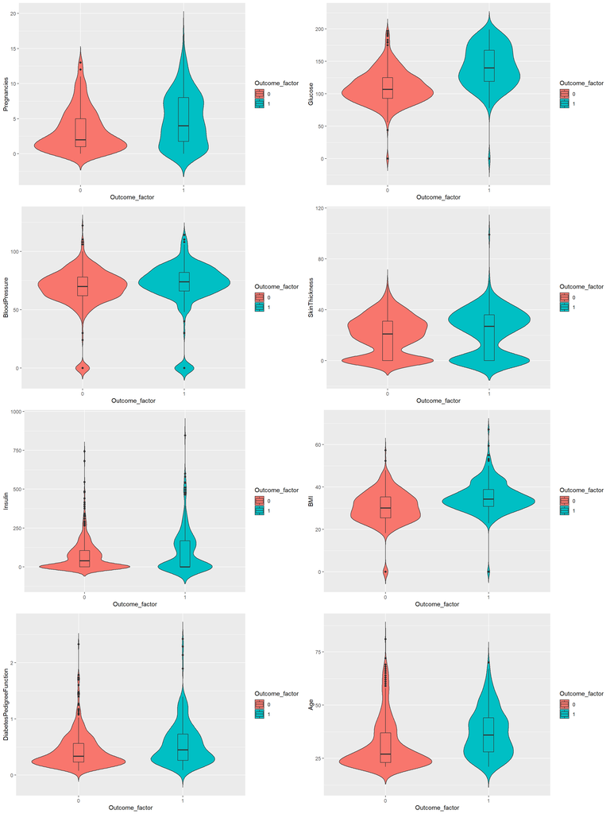

```r
p1 <- ggplot(data, aes(x=Outcome_factor, y=Pregnancies, fill=Outcome_factor)) +
  geom_violin(trim=FALSE)+
  geom_boxplot(width=0.1)


p2 <- ggplot(data, aes(x=Outcome_factor, y=Glucose, fill=Outcome_factor)) +
  geom_violin(trim=FALSE)+
  geom_boxplot(width=0.1)

p3 <- ggplot(data, aes(x=Outcome_factor, y=BloodPressure, fill=Outcome_factor)) +
  geom_violin(trim=FALSE)+
  geom_boxplot(width=0.1)

p4 <- ggplot(data, aes(x=Outcome_factor, y=SkinThickness, fill=Outcome_factor)) +
  geom_violin(trim=FALSE)+
  geom_boxplot(width=0.1)

p5 <- ggplot(data, aes(x=Outcome_factor, y=Insulin, fill=Outcome_factor)) +
  geom_violin(trim=FALSE)+
  geom_boxplot(width=0.1)

p6 <- ggplot(data, aes(x=Outcome_factor, y=BMI, fill=Outcome_factor)) +
  geom_violin(trim=FALSE)+
  geom_boxplot(width=0.1)

p7 <- ggplot(data, aes(x=Outcome_factor, y=DiabetesPedigreeFunction, fill=Outcome_factor)) +
  geom_violin(trim=FALSE)+
  geom_boxplot(width=0.1)

p8 <- ggplot(data, aes(x=Outcome_factor, y=Age, fill=Outcome_factor)) +
  geom_violin(trim=FALSE)+
  geom_boxplot(width=0.1)


grid.arrange(p1, p2, p3, p4, p5, p6, p7, p8, ncol=2)
```

The response variable has been plotted to show the percentage of diabetic and non-diabetic people.

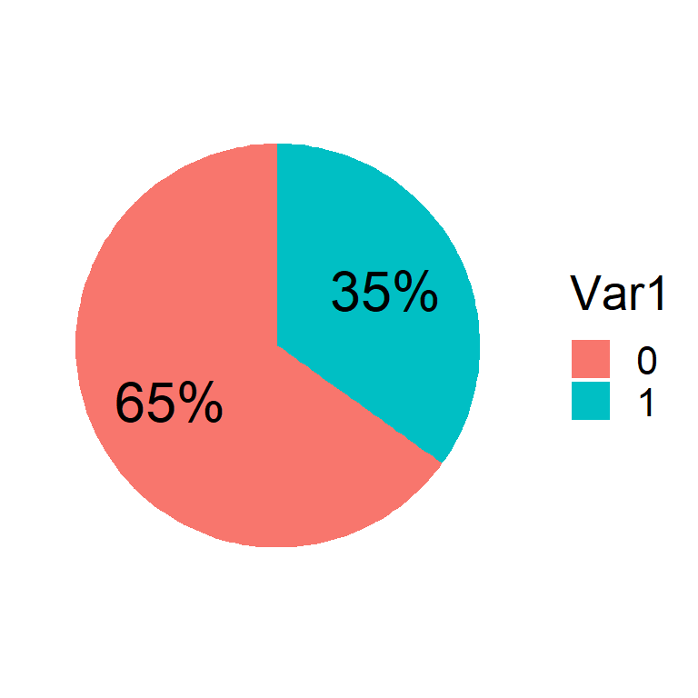

```r
# Response variable
blank_theme <- theme_minimal()+
  theme(
    axis.title.x = element_blank(),
    axis.title.y = element_blank(),
    panel.border = element_blank(),
    panel.grid=element_blank(),
    axis.ticks = element_blank(),
    plot.title=element_text(size=14, face="bold")
  )

pie_data <- as.data.frame(table(data$Outcome))
pie_data$perc <- round(pie_data$Freq / sum(pie_data$Freq),2)*100
bp<- ggplot(pie_data, aes(x="", y=Freq, fill=Var1))+
  geom_bar(width = 1, stat = "identity")
pie <- bp + coord_polar("y", start=0) + theme_minimal()+blank_theme+ theme(axis.text.x=element_blank()) +
  geom_text(aes(x=1.1, label = paste(perc,"%",sep="")), size=8, position = position_stack(vjust = .5)) + theme(legend.position="right") +
  theme(
    text = element_text(size=20),
    plot.title = element_text(size=30)
  )
pie
```

### The Model

Our first model is a logistic regression, As follow:

$$\begin{eqnarray*}
y=y_{1} \ldots y_{n} \sim \text { Bernoulli }(\pi) \\
\operatorname{logit}(\pi)=\log \left(\frac{\pi}{1-\pi}\right)=\beta_{0}+\beta_{1} X_{1}+\beta_{2} X_{2}+\beta_{3} X_{3}+\beta_{4} X_{4}+\beta_{5} X_{5}+\beta_{6} X_{6}+\beta_{7} X_{7}+\beta_{8} X_{8} \\
\beta_{0} \sim N(0,0.000001) \\
\beta_{1} \sim N(0,0.000001) \\
\beta_{2} \sim N(0,0.000001) \\
\beta_{3} \sim N(0,0.000001) \\
\beta_{4} \sim N(0,0.000001) \\
\beta_{5} \sim N(0,0.000001) \\
\beta_{6} \sim N(0,0.000001) \\
\beta_{7} \sim N(0,0.000001) \\
\beta_{8} \sim N(0,0.000001)
\end{eqnarray*}$$

Here we need to estimating the $\beta$s in order to predict weather the person is diabetic or not.

```r
#### Fit a Bayesian logit model####
# Define the model

#Identify filepath of model file
modfile_logit <- tempfile()

#Write model to file
writeLines("
model{

  # Likelihood
  for (i in 1:N){
    y[i] ~ dbern(pi[i])

    logit(pi[i]) <- beta_0 + beta_1*x1[i] + beta_2*x2[i] + beta_3*x3[i] + beta_4*x4[i] + beta_5*x5[i] + beta_6*x6[i] + beta_7*x7[i] + beta_8*x8[i]
  }

  # Define prior for intercept
  beta_0 ~ dnorm(0, 1.0E-6)

  # Define prior for beta1 (Pregnancies)
  beta_1 ~ dnorm(0, 1.0E-6)

  # Define prior for beta2 (Glucose)
  beta_2 ~ dnorm(0, 1.0E-6)

  # Define prior for beta3 (BloodPressure)
  beta_3 ~ dnorm(0, 1.0E-6)

  # Define prior for beta4 (SkinThickness)
  beta_4 ~ dnorm(0, 1.0E-6)

  # Define prior for beta5 (Insulin)
  beta_5 ~ dnorm(0, 1.0E-6)

  # Define prior for beta6 (BMI)
  beta_6 ~ dnorm(0, 1.0E-6)

  # Define prior for beta7 (DiabetesPedigreeFunction)
  beta_7~ dnorm(0, 1.0E-6)

  # Define prior for beta8 (Age)
  beta_8 ~ dnorm(0, 1.0E-6)

}
", con = modfile_logit)
```

Then we should Prepare data for JAGS

```r
# Set number of individuals
N <- dim(data)[1]

# Response variable
y <- as.vector(as.numeric(as.character(data$Outcome)))

data_jags <- list("y" = y, "N" = N, "x1" = data$Pregnancies
                  , "x2" = data$Glucose
                  , "x3" = data$BloodPressure
                  , "x4" = data$SkinThickness
                  , "x5" = data$Insulin
                  , "x6" = data$BMI
                  , "x7" = data$DiabetesPedigreeFunction
                  , "x8" = data$Age
                  )

# Defining parameters of interest
parameters <- c("beta_0", "beta_1", "beta_2", "beta_3", "beta_4", "beta_5", "beta_6", "beta_7", "beta_8")

# Fit model with JAGS
set.seed(seed)
mod_fit_logit <- jags(data = data_jags,
                         model.file = modfile_logit,
                         parameters.to.save = parameters,
                         n.chains = 1, n.iter = 10000, n.burnin = 1000)
```

```
##
## Processing function input.......
##
## Done.
##
##
##
## Adaptive phase.....
## Adaptive phase complete
##
##
##  Burn-in phase, 1000 iterations x 1 chains
##
##
## Sampling from joint posterior, 9000 iterations x 1 chains
##
##
## Calculating statistics.......
```

```
##
## Done.
```

```r
# Get AIC of the model
mod_fit_logit$DIC
```

```
## [1] 741.5583
```

```r
# Get summary of the model
mod_fit_logit$summary
```

```
##                    mean           sd          2.5%           25%            50%
## beta_0    -8.5351055950 0.7201942727  -9.966422676  -9.008230328  -8.5273379316
## beta_1     0.1235286076 0.0318740427   0.062377234   0.101818761   0.1234305626
## beta_2     0.0356359524 0.0037581719   0.028352900   0.033103015   0.0355556260
## beta_3    -0.0134212251 0.0051985144  -0.023589246  -0.016949164  -0.0133545855
## beta_4     0.0005689307 0.0068626408  -0.012702320  -0.004074781   0.0005289531
## beta_5    -0.0011912417 0.0009086335  -0.003006400  -0.001800512  -0.0011902933
## beta_6     0.0913138479 0.0153765685   0.061248248   0.080852771   0.0911424340
## beta_7     0.9669438236 0.2980373945   0.378023052   0.770027522   0.9653767433
## beta_8     0.0151665219 0.0095617330  -0.003819652   0.008676603   0.0152239237
## deviance 732.4529465065 4.2674047292 726.159584134 729.339738731 731.7602224685
##                    75%          97.5% overlap0         f
## beta_0    -8.039349400  -7.1687441528        0 1.0000000
## beta_1     0.144562455   0.1883197005        0 0.9998889
## beta_2     0.038149912   0.0432528731        0 1.0000000
## beta_3    -0.009911649  -0.0031999222        0 0.9956667
## beta_4     0.005194639   0.0141190071        1 0.5305556
## beta_5    -0.000577894   0.0005766163        1 0.9050000
## beta_6     0.101719114   0.1218505427        0 1.0000000
## beta_7     1.172111088   1.5471616527        0 0.9994444
## beta_8     0.021541708   0.0340894666        1 0.9427778
## deviance 734.803615487 742.3281684714        0 1.0000000
```

As we see in the summary, 3 covariates detect as non significant in the model.

So we want to run a new logit model and remove the covariates that detect as non significant in the previous model.

```r
####### Defining second logit model by dropping non-significant covariates #######

# Define model
#Identify filepath of model file
modfile_logit2 <- tempfile()

#Write model to file
writeLines("
model{

  # Likelihood
  for (i in 1:N){
    y[i] ~ dbern(pi[i])

    logit(pi[i]) <- beta_0 + beta_1*x1[i] + beta_2*x2[i] + beta_3*x3[i] + beta_4*x4[i] + beta_5*x5[i]
  }

  # Define prior for intercept
  beta_0 ~ dnorm(0, 1.0E-6)

  # Define prior for beta1 (Pregnancies)
  beta_1 ~ dnorm(0, 1.0E-6)

  # Define prior for beta2 (Glucose)
  beta_2 ~ dnorm(0, 1.0E-6)

  # Define prior for beta3 (BloodPressure)
  beta_3 ~ dnorm(0, 1.0E-6)

  # Define prior for beta4 (BMI)
  beta_4 ~ dnorm(0, 1.0E-6)

  # Define prior for beta5 (DiabetesPedigreeFunction)
  beta_5~ dnorm(0, 1.0E-6)


}
", con = modfile_logit2)


# Preparing data for JAGS
# Set number of individuals
N <- dim(data)[1]

# Response variable
y <- as.vector(as.numeric(as.character(data$Outcome))) # Target variable, risks heart attack?

data_jags2 <- list("y" = y, "N" = N, "x1" = data$Pregnancies
                  , "x2" = data$Glucose
                  , "x3" = data$BloodPressure
                  , "x4" = data$BMI
                  , "x5" = data$DiabetesPedigreeFunction
)

# Defining parameters of interest
parameters2 <- c("beta_0", "beta_1", "beta_2", "beta_3", "beta_4", "beta_5")

# Fit model with JAGS
set.seed(seed)
mod_fit_logit2 <- jags(data = data_jags2,
                      model.file = modfile_logit2,
                      parameters.to.save = parameters2,
                      n.chains = 1, n.iter = 10000, n.burnin = 1000)
```

```
##
## Processing function input.......
##
## Done.
##
##
##
## Adaptive phase.....
## Adaptive phase complete
##
##
##  Burn-in phase, 1000 iterations x 1 chains
##
##
## Sampling from joint posterior, 9000 iterations x 1 chains
##
##
## Calculating statistics.......
```

```
##
## Done.
```

```r
# Get AIC of the model
mod_fit_logit2$DIC
```

```
## [1] 740.7054
```

```r
# Get summary of the model
mod_fit_logit2$summary
```

```
##                  mean          sd         2.5%          25%          50%
## beta_0    -8.05943497 0.675430352  -9.41031432  -8.50296051  -8.03607980
## beta_1     0.15471519 0.028133178   0.10034583   0.13567008   0.15411043
## beta_2     0.03509941 0.003394173   0.02861040   0.03280083   0.03501539
## beta_3    -0.01205678 0.005182925  -0.02222432  -0.01562135  -0.01208179
## beta_4     0.08609905 0.014376839   0.05837308   0.07641603   0.08575237
## beta_5     0.91607554 0.293794870   0.34479603   0.72031005   0.91300224
## deviance 734.62726790 3.486576817 729.80246612 732.09327156 733.99010074
##                    75%         97.5% overlap0         f
## beta_0    -7.597541428  -6.783780468        0 1.0000000
## beta_1     0.173744128   0.209765610        0 1.0000000
## beta_2     0.037341272   0.041988992        0 1.0000000
## beta_3    -0.008498461  -0.001883908        0 0.9914444
## beta_4     0.095614463   0.114960104        0 1.0000000
## beta_5     1.113716163   1.484305172        0 0.9991111
## deviance 736.429758821 742.978674979        0 1.0000000
```

As we see the DIC of the second model is lower than the DIC of the first one, so we conclude that the second model is a better model. From the summary we can see that all the covariates are significant.

Below we see the plotted results of the second model.

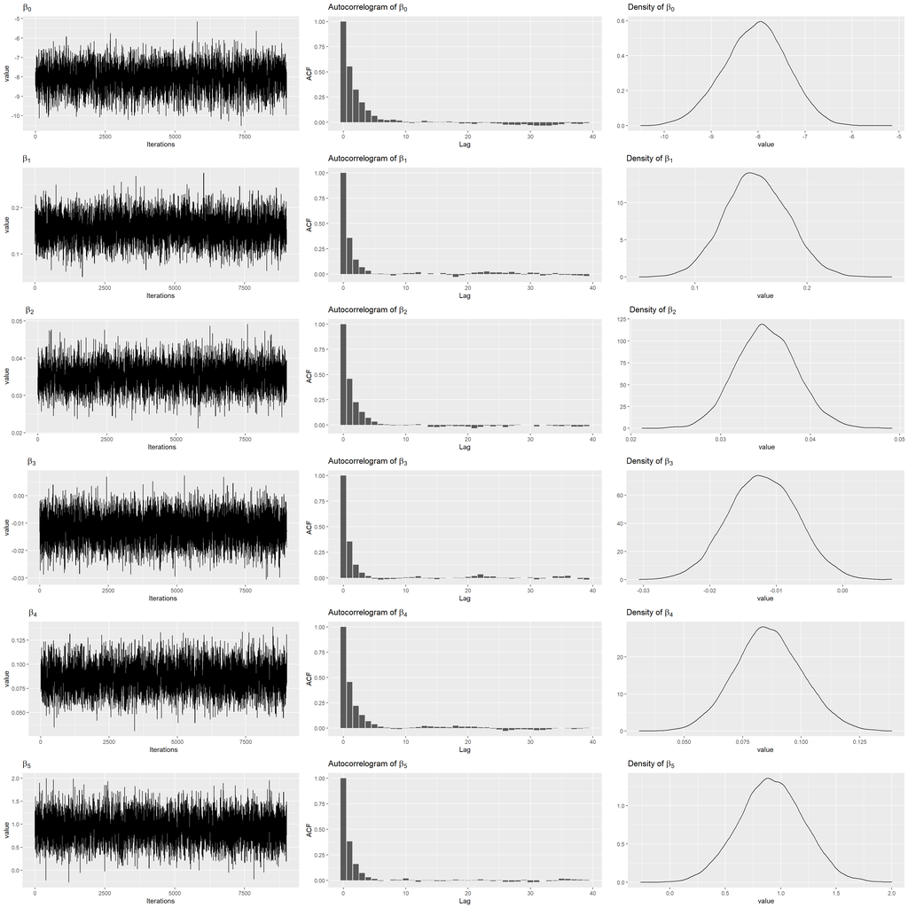

```r
g1 <- ggplot(data=as.data.frame(mod_fit_logit2$sims.list$beta_0), aes(x=seq(1,9000),y=mod_fit_logit2$sims.list$beta_0, group=1)) +
  geom_line()+ xlab("Iterations")+ ylab("value")+
  labs(title=expression(paste("",beta[0])))


g2 <- ggplot(as.data.frame(mod_fit_logit2$sims.list$beta_0), aes(x=mod_fit_logit2$sims.list$beta_0))+
  geom_density()+xlab("value")+ ylab("")+
  labs(title=expression(paste("Density of ",beta[0])))


bacf <- acf(mod_fit_logit2$sims.list$beta_0, plot = FALSE)
bacfdf <- with(bacf, data.frame(lag, acf))

g3 <- ggplot(data=bacfdf, mapping=aes(x=lag, y=acf)) +
  geom_bar(stat = "identity", position = "identity")+
  xlab("Lag")+ ylab("ACF")+labs(title=expression(paste("Autocorrelogram of ",beta[0])))

g4 <- ggplot(data=as.data.frame(mod_fit_logit2$sims.list$beta_1)
             , aes(x=seq(1,9000),y=mod_fit_logit2$sims.list$beta_1, group=1)) +
  geom_line()+ xlab("Iterations")+ ylab("value")+
  labs(title=expression(paste("",beta[1])))

g5 <- ggplot(as.data.frame(mod_fit_logit2$sims.list$beta_1)
             , aes(x=mod_fit_logit2$sims.list$beta_1))+
  geom_density()+xlab("value")+ ylab("")+
  labs(title=expression(paste("Density of ",beta[1])))

bacf <- acf(mod_fit_logit2$sims.list$beta_1, plot = FALSE)
bacfdf <- with(bacf, data.frame(lag, acf))

g6 <- ggplot(data=bacfdf, mapping=aes(x=lag, y=acf)) +
  geom_bar(stat = "identity", position = "identity")+
  xlab("Lag")+ ylab("ACF")+
  labs(title=expression(paste("Autocorrelogram of ",beta[1])))

g7 <- ggplot(data=as.data.frame(mod_fit_logit2$sims.list$beta_2)
             , aes(x=seq(1,9000),y=mod_fit_logit2$sims.list$beta_2, group=1)) +
  geom_line()+ xlab("Iterations")+ ylab("value")+
  labs(title=expression(paste("",beta[2])))

g8 <- ggplot(as.data.frame(mod_fit_logit2$sims.list$beta_2)
             , aes(x=mod_fit_logit2$sims.list$beta_2))+
  geom_density()+xlab("value")+ ylab("")+
  labs(title=expression(paste("Density of ",beta[2])))


bacf <- acf(mod_fit_logit2$sims.list$beta_2, plot = FALSE)
bacfdf <- with(bacf, data.frame(lag, acf))

g9 <- ggplot(data=bacfdf, mapping=aes(x=lag, y=acf)) +
  geom_bar(stat = "identity", position = "identity")+
  xlab("Lag")+ ylab("ACF")+
  labs(title=expression(paste("Autocorrelogram of ",beta[2])))

g10 <- ggplot(data=as.data.frame(mod_fit_logit2$sims.list$beta_3)
              , aes(x=seq(1,9000),y=mod_fit_logit2$sims.list$beta_3, group=1)) +
  geom_line()+ xlab("Iterations")+ ylab("value")+
  labs(title=expression(paste("",beta[3])))

g11 <- ggplot(as.data.frame(mod_fit_logit2$sims.list$beta_3)
              , aes(x=mod_fit_logit2$sims.list$beta_3))+
  geom_density()+xlab("value")+ ylab("")+
  labs(title=expression(paste("Density of ",beta[3])))


bacf <- acf(mod_fit_logit2$sims.list$beta_3, plot = FALSE)
bacfdf <- with(bacf, data.frame(lag, acf))

g12 <- ggplot(data=bacfdf, mapping=aes(x=lag, y=acf)) +
  geom_bar(stat = "identity", position = "identity")+
  xlab("Lag")+ ylab("ACF")+
  labs(title=expression(paste("Autocorrelogram of ",beta[3])))

g13 <- ggplot(data=as.data.frame(mod_fit_logit2$sims.list$beta_4)
              , aes(x=seq(1,9000),y=mod_fit_logit2$sims.list$beta_4, group=1)) +
  geom_line()+ xlab("Iterations")+ ylab("value")+
  labs(title=expression(paste("",beta[4])))

g14 <- ggplot(as.data.frame(mod_fit_logit2$sims.list$beta_4)
              , aes(x=mod_fit_logit2$sims.list$beta_4))+
  geom_density()+xlab("value")+ ylab("")+
  labs(title=expression(paste("Density of ",beta[4])))


bacf <- acf(mod_fit_logit2$sims.list$beta_4, plot = FALSE)
bacfdf <- with(bacf, data.frame(lag, acf))

g15 <- ggplot(data=bacfdf, mapping=aes(x=lag, y=acf)) +
  geom_bar(stat = "identity", position = "identity")+
  xlab("Lag")+ ylab("ACF")+
  labs(title=expression(paste("Autocorrelogram of ",beta[4])))

g16 <- ggplot(data=as.data.frame(mod_fit_logit2$sims.list$beta_5)
              , aes(x=seq(1,9000),y=mod_fit_logit2$sims.list$beta_5, group=1)) +
  geom_line()+ xlab("Iterations")+ ylab("value")+
  labs(title=expression(paste("",beta[5])))

g17 <- ggplot(as.data.frame(mod_fit_logit2$sims.list$beta_5)
              , aes(x=mod_fit_logit2$sims.list$beta_5))+
  geom_density()+xlab("value")+ ylab("")+
  labs(title=expression(paste("Density of ",beta[5])))


bacf <- acf(mod_fit_logit2$sims.list$beta_5, plot = FALSE)
bacfdf <- with(bacf, data.frame(lag, acf))

g18 <- ggplot(data=bacfdf, mapping=aes(x=lag, y=acf)) +
  geom_bar(stat = "identity", position = "identity")+
  xlab("Lag")+ ylab("ACF")+
  labs(title=expression(paste("Autocorrelogram of ",beta[5])))

grid.arrange(g1, g3, g2,g4,g6,g5,g7,g9, g8, g10,g12,g11,g13,g15,g14,g16,g18,g17, ncol=3)
```

Here we want to check the correlation between the parameters to make sure that we don’t have too much correlation.

```r
union_logit <- as.mcmc(cbind(beta_0=mod_fit_logit2$sims.list$beta_0
                       ,beta_1=mod_fit_logit2$sims.list$beta_1
                       ,beta_2=mod_fit_logit2$sims.list$beta_2
                       ,beta_3=mod_fit_logit2$sims.list$beta_3
                       ,beta_4=mod_fit_logit2$sims.list$beta_4
                       ,beta_5=mod_fit_logit2$sims.list$beta_5))

# Correlation matrix of parameters
data_corr <- as.data.frame(union_logit)
names(data_corr) <- c("beta_0","beta_1","beta_2","beta_3","beta_4","beta_5")
cormat <- round(cor(data_corr),2)
cormat
```

```
##        beta_0 beta_1 beta_2 beta_3 beta_4 beta_5
## beta_0   1.00  -0.24  -0.56  -0.23  -0.59  -0.21
## beta_1  -0.24   1.00   0.05  -0.20   0.18   0.07
## beta_2  -0.56   0.05   1.00  -0.14  -0.02   0.04
## beta_3  -0.23  -0.20  -0.14   1.00  -0.24  -0.02
## beta_4  -0.59   0.18  -0.02  -0.24   1.00  -0.04
## beta_5  -0.21   0.07   0.04  -0.02  -0.04   1.00
```

As we can see here, we don’t have too much correlation between the parameters.

### Model checking diagnostics

The first test is effective sample size which tells us the number of independent observations for our sample that we should have in order to remove the autocorrelation.

```r
effectiveSize(union_logit)
```

```
##   beta_0   beta_1   beta_2   beta_3   beta_4   beta_5
## 2455.674 4126.409 3075.578 4278.506 3084.999 3898.812
```

The next test is Geweke test. By this test we want to know that if the burn-in period we choose is enough to converge the markov chain or not.

```r
geweke_df <- rbind(geweke.diag(union_logit)$z,pnorm(abs(geweke.diag(union_logit)$z),lower.tail=FALSE)*2)
geweke_df
```

```
##         beta_0     beta_1     beta_2     beta_3     beta_4    beta_5
## [1,] 0.3596062 -0.1627221 -0.4090803 -0.2503231 -0.3487223 1.4296234
## [2,] 0.7191416  0.8707373  0.6824807  0.8023375  0.7272978 0.1528251
```

All the p-values are greater than our critical value (0.05) so the iterations that we choose for the burn-in period for all of the covariates are enough.

Below we see the plotted results of the geweke test:

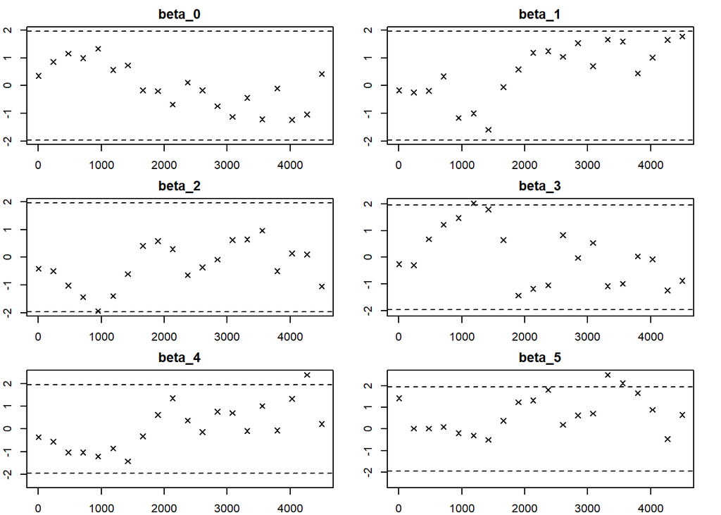

```r
par(mar=c(2,2,2,2))
par(mfrow=c(1,1))
geweke.plot(union_logit)
```

The next test to perform is Raftery test. By this test we check two things:  
1. The minimum iterations we need for the burn-in period.  
2. The minimum sample size that we should consider for the markov chain.

```r
raftery.diag(union_logit)
```

```
##
## Quantile (q) = 0.025
## Accuracy (r) = +/- 0.005
## Probability (s) = 0.95
##
##         Burn-in  Total Lower bound  Dependence
##         (M)      (N)   (Nmin)       factor (I)
##  beta_0 5        5651  3746         1.51
##  beta_1 3        4159  3746         1.11
##  beta_2 3        4516  3746         1.21
##  beta_3 3        4275  3746         1.14
##  beta_4 3        4516  3746         1.21
##  beta_5 3        4394  3746         1.17
```

As we see both burn-in period and the sample size for the markov chain for all the covariates are greater than the minimum.

The last test we want to do is the Heidel test. This is a test to find out weather our markov chain is stationary and converged or not.

```r
heidel.diag(union_logit)
```

```
##
##        Stationarity start     p-value
##        test         iteration
## beta_0 passed       1         0.582
## beta_1 passed       1         0.196
## beta_2 passed       1         0.422
## beta_3 passed       1         0.682
## beta_4 passed       1         0.503
## beta_5 passed       1         0.187
##
##        Halfwidth Mean    Halfwidth
##        test
## beta_0 passed    -8.0594 0.026715
## beta_1 passed     0.1547 0.000858
## beta_2 passed     0.0351 0.000120
## beta_3 passed    -0.0121 0.000155
## beta_4 passed     0.0861 0.000507
## beta_5 passed     0.9161 0.009222
```

As we see from the above table, all the covariates passed the test.

### Probit Model

For the next step we want try also the probit model to see which one works better for our data.

Our model is a probit regression, As follow:

```r
####### Defining the probit model #######

# Define model
#Identify filepath of model file
modfile_probit <- tempfile()

#Write model to file
writeLines("
model{

  # Likelihood
  for (i in 1:N){
    y[i] ~ dbern(pi[i])

    probit(pi[i]) <- beta_0 + beta_1*x1[i] + beta_2*x2[i] + beta_3*x3[i] + beta_4*x4[i] + beta_5*x5[i]
  }

  # Define prior for intercept
  beta_0 ~ dnorm(0, 1.0E-6)

  # Define prior for beta1 (Pregnancies)
  beta_1 ~ dnorm(0, 1.0E-6)

  # Define prior for beta2 (Glucose)
  beta_2 ~ dnorm(0, 1.0E-6)

  # Define prior for beta3 (BloodPressure)
  beta_3 ~ dnorm(0, 1.0E-6)

  # Define prior for beta4 (BMI)
  beta_4 ~ dnorm(0, 1.0E-6)

  # Define prior for beta5 (DiabetesPedigreeFunction)
  beta_5~ dnorm(0, 1.0E-6)


}
", con = modfile_probit)


# Preparing data for JAGS
# Set number of individuals
N <- dim(data)[1]

# Response variable
y <- as.vector(as.numeric(as.character(data$Outcome)))

data_jags2 <- list("y" = y, "N" = N, "x1" = data$Pregnancies
                   , "x2" = data$Glucose
                   , "x3" = data$BloodPressure
                   , "x4" = data$BMI
                   , "x5" = data$DiabetesPedigreeFunction
)

# Defining parameters of interest
parameters2 <- c("beta_0", "beta_1", "beta_2", "beta_3", "beta_4", "beta_5")

# Fit model with JAGS
set.seed(seed)
mod_fit_probit <- jags(data = data_jags2,
                       model.file = modfile_probit,
                       parameters.to.save = parameters2,
                       n.chains = 1, n.iter = 10000, n.burnin = 1000)
```

```
##
## Processing function input.......
##
## Done.
##
##
##
## Adaptive phase.....
## Adaptive phase complete
##
##
##  Burn-in phase, 1000 iterations x 1 chains
##
##
## Sampling from joint posterior, 9000 iterations x 1 chains
##
##
## Calculating statistics.......
##
## Done.
```

```r
# Get AIC of the model
mod_fit_probit$DIC
```

```
## [1] 744.0916
```

```r
# Get summary of the model
mod_fit_probit$summary
```

```
##                   mean          sd         2.5%           25%           50%
## beta_0    -4.604860577 0.360169363  -5.32562356  -4.839797380  -4.602342460
## beta_1     0.091816033 0.016018469   0.05990876   0.081208976   0.091732958
## beta_2     0.019679806 0.001805204   0.01611254   0.018471507   0.019685590
## beta_3    -0.006730867 0.002972874  -0.01264504  -0.008742373  -0.006697348
## beta_4     0.050186739 0.007904266   0.03480612   0.044852718   0.050166578
## beta_5     0.470827598 0.161553965   0.15764176   0.362196254   0.468418613
## deviance 737.934590789 3.509123478 733.14870767 735.337993784 737.292594335
##                    75%          97.5% overlap0         f
## beta_0    -4.364868492  -3.9027854952        0 1.0000000
## beta_1     0.102666219   0.1229769454        0 1.0000000
## beta_2     0.020895156   0.0231611838        0 1.0000000
## beta_3    -0.004724561  -0.0009890555        0 0.9892222
## beta_4     0.055457837   0.0660585418        0 1.0000000
## beta_5     0.579283069   0.7914474277        0 0.9985556
## deviance 739.783772429 746.4865667541        0 1.0000000
```

Based on the results we can say that the logit model performs better than the probit model.

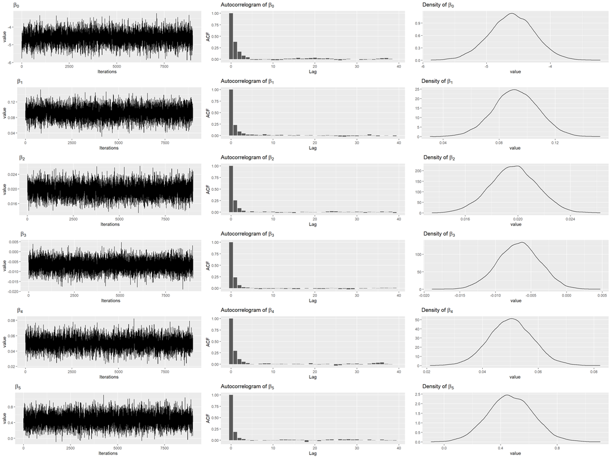

```r
g1 <- ggplot(data=as.data.frame(mod_fit_probit$sims.list$beta_0), aes(x=seq(1,9000),y=mod_fit_probit$sims.list$beta_0, group=1)) +
  geom_line()+ xlab("Iterations")+ ylab("value")+
  labs(title=expression(paste("",beta[0])))


g2 <- ggplot(as.data.frame(mod_fit_probit$sims.list$beta_0), aes(x=mod_fit_probit$sims.list$beta_0))+
  geom_density()+xlab("value")+ ylab("")+
  labs(title=expression(paste("Density of ",beta[0])))


bacf <- acf(mod_fit_probit$sims.list$beta_0, plot = FALSE)
bacfdf <- with(bacf, data.frame(lag, acf))

g3 <- ggplot(data=bacfdf, mapping=aes(x=lag, y=acf)) +
  geom_bar(stat = "identity", position = "identity")+
  xlab("Lag")+ ylab("ACF")+labs(title=expression(paste("Autocorrelogram of ",beta[0])))

g4 <- ggplot(data=as.data.frame(mod_fit_probit$sims.list$beta_1)
             , aes(x=seq(1,9000),y=mod_fit_probit$sims.list$beta_1, group=1)) +
  geom_line()+ xlab("Iterations")+ ylab("value")+
  labs(title=expression(paste("",beta[1])))

g5 <- ggplot(as.data.frame(mod_fit_probit$sims.list$beta_1)
             , aes(x=mod_fit_probit$sims.list$beta_1))+
  geom_density()+xlab("value")+ ylab("")+
  labs(title=expression(paste("Density of ",beta[1])))

bacf <- acf(mod_fit_probit$sims.list$beta_1, plot = FALSE)
bacfdf <- with(bacf, data.frame(lag, acf))

g6 <- ggplot(data=bacfdf, mapping=aes(x=lag, y=acf)) +
  geom_bar(stat = "identity", position = "identity")+
  xlab("Lag")+ ylab("ACF")+
  labs(title=expression(paste("Autocorrelogram of ",beta[1])))

g7 <- ggplot(data=as.data.frame(mod_fit_probit$sims.list$beta_2)
             , aes(x=seq(1,9000),y=mod_fit_probit$sims.list$beta_2, group=1)) +
  geom_line()+ xlab("Iterations")+ ylab("value")+
  labs(title=expression(paste("",beta[2])))

g8 <- ggplot(as.data.frame(mod_fit_probit$sims.list$beta_2)
             , aes(x=mod_fit_probit$sims.list$beta_2))+
  geom_density()+xlab("value")+ ylab("")+
  labs(title=expression(paste("Density of ",beta[2])))


bacf <- acf(mod_fit_probit$sims.list$beta_2, plot = FALSE)
bacfdf <- with(bacf, data.frame(lag, acf))

g9 <- ggplot(data=bacfdf, mapping=aes(x=lag, y=acf)) +
  geom_bar(stat = "identity", position = "identity")+
  xlab("Lag")+ ylab("ACF")+
  labs(title=expression(paste("Autocorrelogram of ",beta[2])))

g10 <- ggplot(data=as.data.frame(mod_fit_probit$sims.list$beta_3)
              , aes(x=seq(1,9000),y=mod_fit_probit$sims.list$beta_3, group=1)) +
  geom_line()+ xlab("Iterations")+ ylab("value")+
  labs(title=expression(paste("",beta[3])))

g11 <- ggplot(as.data.frame(mod_fit_probit$sims.list$beta_3)
              , aes(x=mod_fit_probit$sims.list$beta_3))+
  geom_density()+xlab("value")+ ylab("")+
  labs(title=expression(paste("Density of ",beta[3])))


bacf <- acf(mod_fit_probit$sims.list$beta_3, plot = FALSE)
bacfdf <- with(bacf, data.frame(lag, acf))

g12 <- ggplot(data=bacfdf, mapping=aes(x=lag, y=acf)) +
  geom_bar(stat = "identity", position = "identity")+
  xlab("Lag")+ ylab("ACF")+
  labs(title=expression(paste("Autocorrelogram of ",beta[3])))

g13 <- ggplot(data=as.data.frame(mod_fit_probit$sims.list$beta_4)
              , aes(x=seq(1,9000),y=mod_fit_probit$sims.list$beta_4, group=1)) +
  geom_line()+ xlab("Iterations")+ ylab("value")+
  labs(title=expression(paste("",beta[4])))

g14 <- ggplot(as.data.frame(mod_fit_probit$sims.list$beta_4)
              , aes(x=mod_fit_probit$sims.list$beta_4))+
  geom_density()+xlab("value")+ ylab("")+
  labs(title=expression(paste("Density of ",beta[4])))


bacf <- acf(mod_fit_probit$sims.list$beta_4, plot = FALSE)
bacfdf <- with(bacf, data.frame(lag, acf))

g15 <- ggplot(data=bacfdf, mapping=aes(x=lag, y=acf)) +
  geom_bar(stat = "identity", position = "identity")+
  xlab("Lag")+ ylab("ACF")+
  labs(title=expression(paste("Autocorrelogram of ",beta[4])))

g16 <- ggplot(data=as.data.frame(mod_fit_probit$sims.list$beta_5)
              , aes(x=seq(1,9000),y=mod_fit_probit$sims.list$beta_5, group=1)) +
  geom_line()+ xlab("Iterations")+ ylab("value")+
  labs(title=expression(paste("",beta[5])))

g17 <- ggplot(as.data.frame(mod_fit_probit$sims.list$beta_5)
              , aes(x=mod_fit_probit$sims.list$beta_5))+
  geom_density()+xlab("value")+ ylab("")+
  labs(title=expression(paste("Density of ",beta[5])))


bacf <- acf(mod_fit_probit$sims.list$beta_5, plot = FALSE)
bacfdf <- with(bacf, data.frame(lag, acf))

g18 <- ggplot(data=bacfdf, mapping=aes(x=lag, y=acf)) +
  geom_bar(stat = "identity", position = "identity")+
  xlab("Lag")+ ylab("ACF")+
  labs(title=expression(paste("Autocorrelogram of ",beta[5])))

grid.arrange(g1, g3, g2,g4,g6,g5,g7,g9, g8, g10,g12,g11,g13,g15,g14,g16,g18,g17, ncol=3)
```

### Frequentist Model

Here we want to try the Frequentist approach.

```r
# Fitting Frequentist logistic regression model
fre_mod_fit_logit <- glm(factor(Outcome)~Pregnancies+Glucose+BloodPressure+BMI+DiabetesPedigreeFunction,data = data,family = binomial())
summary(fre_mod_fit_logit)
```

```
##
## Call:
## glm(formula = factor(Outcome) ~ Pregnancies + Glucose + BloodPressure +
##     BMI + DiabetesPedigreeFunction, family = binomial(), data = data)
##
## Deviance Residuals:
##     Min       1Q   Median       3Q      Max
## -2.7931  -0.7362  -0.4188   0.7251   2.9555
##
## Coefficients:
##                           Estimate Std. Error z value             Pr(>|z|)
## (Intercept)              -7.954952   0.675823 -11.771 < 0.0000000000000002 ***
## Pregnancies               0.153492   0.027835   5.514         0.0000000350 ***
## Glucose                   0.034658   0.003394  10.213 < 0.0000000000000002 ***
## BloodPressure            -0.012007   0.005031  -2.387              0.01700 *
## BMI                       0.084832   0.014125   6.006         0.0000000019 ***
## DiabetesPedigreeFunction  0.910628   0.294027   3.097              0.00195 **
## ---
## Signif. codes:  0 '***' 0.001 '**' 0.01 '*' 0.05 '.' 0.1 ' ' 1
##
## (Dispersion parameter for binomial family taken to be 1)
##
##     Null deviance: 993.48  on 767  degrees of freedom
## Residual deviance: 728.56  on 762  degrees of freedom
## AIC: 740.56
##
## Number of Fisher Scoring iterations: 5
```

```r
AIC(fre_mod_fit_logit)
```

```
## [1] 740.5596
```

By comparing the AIC of the model with the DIC of the previous logit model, we can say that it performed pretty similar.

### Checking the ability of the model to recover true parameters

```r
# Define true parameters
b0 <- -8.05
b1 <- 0.15
b2 <- 0.03
b3 <- -0.012
b4 <- 0.08
b5 <- 0.91
```

Set up the simulation

```r
n_sim <- 10000
set.seed(seed)

x1 <- data$Pregnancies
set.seed(seed)

x2 <- data$Glucose
set.seed(seed)

x3 <- data$BloodPressure
set.seed(seed)

x4 <- data$BMI
set.seed(seed)

x5 <- data$DiabetesPedigreeFunction

z_sim <- b0 + b1*x1 + b2*x2 + b3*x3 + b4*x4 + b5*x5

pi_sim <- 1/(1+exp(-z_sim))
set.seed(seed)
y_sim <- sapply(pi_sim,function(z){rbinom(1,1,z)})
```

Plotting the results

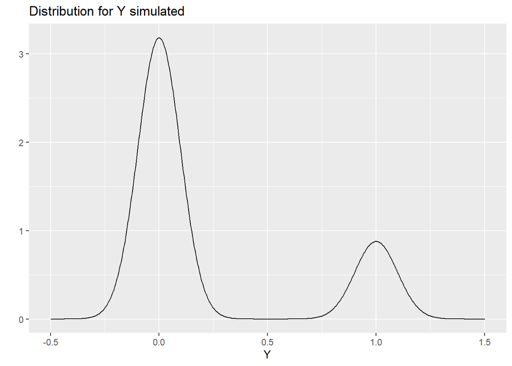

```r
ggplot(as.data.frame(y_sim), aes(x=y_sim))+
  geom_density()+xlab("Y")+ ylab("")+
  labs(title=expression(paste("Distribution for Y simulated")))+
  scale_x_continuous(limits = c(-0.5, 1.5))
```

Check the performance of the estimation.

```r
#Identify filepath of model file
sim_modfile_logit2 <- tempfile()

#Write model to file
writeLines("
model{

  # Likelihood
  for (i in 1:N){
    y[i] ~ dbern(pi[i])

    logit(pi[i]) <- beta_0 + beta_1*x1[i] + beta_2*x2[i] + beta_3*x3[i] + beta_4*x4[i] + beta_5*x5[i]
  }

  # Define prior for intercept
  beta_0 ~ dnorm(0, 1.0E-6)

  # Define prior for beta1 (Pregnancies)
  beta_1 ~ dnorm(0, 1.0E-6)

  # Define prior for beta2 (Glucose)
  beta_2 ~ dnorm(0, 1.0E-6)

  # Define prior for beta3 (BloodPressure)
  beta_3 ~ dnorm(0, 1.0E-6)

  # Define prior for beta4 (BMI)
  beta_4 ~ dnorm(0, 1.0E-6)

  # Define prior for beta5 (DiabetesPedigreeFunction)
  beta_5~ dnorm(0, 1.0E-6)


}
", con = sim_modfile_logit2)


# Preparing data for JAGS
# Set number of individuals
N <- dim(data)[1]

data_jags2_sim <- list("y" = y_sim, "N" = N, "x1" = x1
                   , "x2" = x2
                   , "x3" = x3
                   , "x4" = x4
                   , "x5" = x5
)

# Defining parameters of interest
parameters2 <- c("beta_0", "beta_1", "beta_2", "beta_3", "beta_4", "beta_5")

# Fit model with JAGS
set.seed(seed)
mod_fit_logit2_sim <- jags(data = data_jags2_sim,
                       model.file = sim_modfile_logit2,
                       parameters.to.save = parameters2,
                       n.chains = 1, n.iter = 10000, n.burnin = 1000)
```

```
##
## Processing function input.......
##
## Done.
##
##
##
## Adaptive phase.....
## Adaptive phase complete
##
##
##  Burn-in phase, 1000 iterations x 1 chains
##
##
## Sampling from joint posterior, 9000 iterations x 1 chains
##
##
## Calculating statistics.......
```

```
##
## Done.
```

```r
# Get AIC of the model
mod_fit_logit2_sim$DIC
```

```
## [1] 621.4428
```

```r
# Get summary of the model
mod_fit_logit2_sim$summary
```

```
##                  mean          sd         2.5%          25%          50%
## beta_0    -8.29617564 0.736347876  -9.77276602  -8.78220014  -8.27578656
## beta_1     0.16308298 0.029769576   0.10409972   0.14321475   0.16293401
## beta_2     0.03068404 0.003481418   0.02400836   0.02835211   0.03060683
## beta_3    -0.01197206 0.005337424  -0.02237207  -0.01558124  -0.01200078
## beta_4     0.08652193 0.015766654   0.05622036   0.07606476   0.08637174
## beta_5     0.52257106 0.300771866  -0.06961469   0.31786707   0.52137123
## deviance 615.31860249 3.499771623 610.48252659 612.75358833 614.67620594
##                    75%         97.5% overlap0         f
## beta_0    -7.803514001  -6.898043961        0 1.0000000
## beta_1     0.183179333   0.221044362        0 1.0000000
## beta_2     0.033057904   0.037646296        0 1.0000000
## beta_3    -0.008369212  -0.001415528        0 0.9863333
## beta_4     0.097067090   0.117930973        0 1.0000000
## beta_5     0.725272457   1.113765412        1 0.9595556
## deviance 617.185184210 623.809871160        0 1.0000000
```

### Thanks for your attention